# A Study on Spike Sorting techniques and Analysis

#### 3.2 SPIKE DETECTION

The next step in the spike sorting framework is Spike detection from the filtered data, which is achieved using amplitude discriminators. A commonly applied metric of amplitude, in traditional signal processing applications is to set it to 3-5 times the standard deviation of noise in the data. But the assumption of Gaussian noise need not necessarily hold good at all times, and thus it has been shown that an estimate of amplitude based on median absolute deviation is more robust than one using standard deviation of the noise, and I have adopted the same values for my implementation of MAD

```python
def spike_detection(data, sampling_interval, fs, threshold = 0.5, minimalDist=75, notZero=1e-3):
    '''
    def mad(x):
        return ((np.median(np.abs(x - np.median(x))))/0.6745)
    '''
    print('Detect peaks with amplitude threshold.')
    """
    Performs peak detection on three steps: root mean square, peak to
    average ratios and first order logic.
    threshold used to discard peaks too small
    """
    sigma_noise = np.median(abs(data)/0.6745)
    voltage_threshold = 4.16*sigma_noise
    print('Voltage amplitude threshold - ' + str(voltage_threshold))

    from math import sqrt
    # compute root mean square
    root_mean_square = sqrt(np.sum(np.square(data) / len(data)))
    # compute peak to average ratios
    ratios = np.array([pow(x / root_mean_square, 2) for x in data])
    # apply first order logic
    peaks = (ratios > np.roll(ratios, 1)) & (ratios > np.roll(ratios, -1)) & (ratios > threshold)

    peak_indexes = []
    for i in range(0, len(peaks)):
        if peaks[i] and data[i]>voltage_threshold:
                peak_indexes.append(i)

    T = sampling_interval
    nsamples = T * data.size
    t = np.linspace(0,nsamples,num=fs,endpoint=True)

    plt.plot(t, data, label='filtered signal')
    plt.plot(t[peak_indexes], data[peak_indexes], '*', label='spike')
    plt.plot(t, [voltage_threshold]*t.size, '--',label='voltage_threshold')
    plt.legend()
    plt.show()
    return peak_indexes
```

```
Detect peaks with amplitude threshold.
Voltage amplitude threshold - 9.18290883473e-08
```

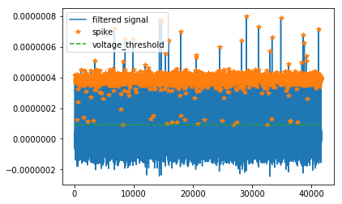

```
2348
Detect peaks with amplitude threshold.
Voltage amplitude threshold - 4.72850962417e-07
```

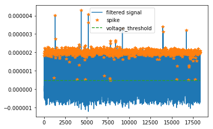

```
1018
```

```python
spikes = spike_detection(data,sampling_interval, data.size)
print(len(spikes))

spikes_c = spike_detection(data_c,sampling_interval, data_c.size)
print(len(spikes_c))
```

Spike detection is followed by separating spike information from the filtered data. The information about a neuron’s refractory period is put to use to identify data samples 1 msec before and after the spike time, to be faithfully characterized as description of a particular spike

```python
def get_spike_features(spikes, data, sampling_interval, fs, plot_type):

    fig = plt.figure()
    ax = plt.subplot(111)
    num_samples_about_spike=int(refractory_period/sampling_interval)
    spike_num_samples=2*(num_samples_about_spike)+1
    print('Each spike has '+ str(spike_num_samples) + ' samples')

    spike_time=np.zeros((len(spikes),spike_num_samples))
    spike_data=np.zeros((len(spikes),spike_num_samples))

    cnt=0
    for l in spikes:

        T = sampling_interval
        nsamples = T * data.size

        t = np.linspace(0,nsamples,num=fs,endpoint=True)

        spike_time[cnt]=t[l-num_samples_about_spike:l+num_samples_about_spike+1]
        spike_data[cnt]=data[l-num_samples_about_spike:l+num_samples_about_spike+1].flatten()

        if(plot_type=='separate'):
            plt.plot(spike_time[cnt], spike_data[cnt], label='Spike-'+str(cnt))
            plt.plot(t[l], data[l], '*', label='spike')
            plt.show()
        elif(plot_type=='together'):
            time=t[0:spike_num_samples]
            plt.plot(time, spike_data[cnt], label='Spike-'+str(cnt))
            plt.show()
        cnt+=1
    return (spike_data,spike_time)
```

```
Each spike has 49 samples
```

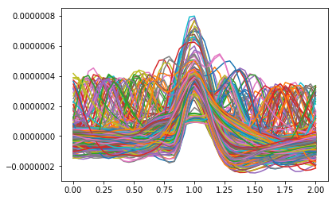

```
(2348, 49)
```

```python
spike_data,spike_time = get_spike_features(spikes,data,sampling_interval, data.size, 'together')
print(spike_data.shape)
spike_df=pd.DataFrame(spike_data)
```

```
Each spike has 49 samples
```

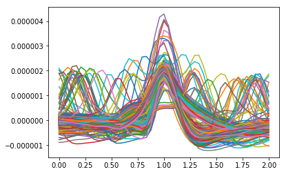

```
(1018, 49)
```

```python
spike_data_c,spike_time_c = get_spike_features(spikes_c,data_c,sampling_interval, data_c.size, 'together')
print(spike_data_c.shape)
spike_df_c=pd.DataFrame(spike_data_c)
```

```python
'''
Combine the 2 spike information
'''
print(spike_df.shape,spike_df_c.shape)
spike_df_temp=spike_df

spike_df = pd.concat([spike_df,spike_df_c])
print(spike_df.shape)
```

```
(2348, 49) (1018, 49)
(3366, 49)
```

#### 3.3 FEATURE EXTRACTION

- After spike detection the filtered data is transformed to spike data which carries the information about individual spikes, which are of very high dimensions that make clustering inefficient. This demands the need for efficient feature extraction methods to map the spike data to a feature space that distinguishes spike properties. Generally, good feature space mapping can thus boost the clustering efficiency.
- PCA finds a feature space as a linear combination of the orthogonal Principal Components, thus giving a projection with maximum variance in the data. The principal components are given by the eigenvectors of the covariance matrix of the data distribution. One of the major drawbacks in applying PCA is that it is susceptible to outliers in data. Also it restricts the data to be represented in a feature space defined by orthogonal co-ordinate axes (Principal Components). Nonetheless, PCA solves for a quick linear transformation to a feature space that is discriminative of the statistical properties in data.
- Locality Preserving Projections are a method of manifold learning that aims to find a linear transformation of the original data by preserving locality information in the newly defined feature space. If the data were to be neatly arranged in a manifold, methods like PCA do not do well in mapping this relationship in comparison to Manifold Learning methods, because of its inability to map nonlinear relationships. LPP allows for a linear mapping that adheres with the goal of manifold learning techniques. This makes LPP robust against outliers, which can be a common problem in spike sorting techniques.

```python
def dim_redn(dataframe, method):

    if( method == 'PCA' ):
        from sklearn.decomposition import PCA
        pca = PCA(n_components=3, whiten=True)
        low_dim_data = pca.fit_transform(dataframe.values)

    elif( method == 'LPP' ):
        from lpproj import LocalityPreservingProjection
        lpp = LocalityPreservingProjection(n_components=3)
        low_dim_data = lpp.fit_transform(dataframe.values)

    print(low_dim_data.shape)
    low_dim_df=pd.DataFrame(low_dim_data)

    m,n = low_dim_data.shape
    idx=np.linspace(0,m-1,m)

    for i in range(n):
            plt.plot(idx, low_dim_df.loc[:,i], label='PC-' + str(i+1))
    plt.legend(loc='best')
    plt.show()


    from mpl_toolkits.mplot3d import Axes3D
    fig = plt.figure()
    ax = fig.add_subplot(111, projection='3d')
    for i in range(m):
        j=0
        while (j+1 < n):
            ax.scatter(low_dim_df.loc[i,j], low_dim_df.loc[i,j+1], c='r', marker='o')
            j+=2

    ax.set_xlabel('PC-1')
    ax.set_ylabel('PC-2')
    ax.set_zlabel('PC-3')
    plt.show()

    return low_dim_df
```

```
PCA RESULTS
(3366, 3)
```

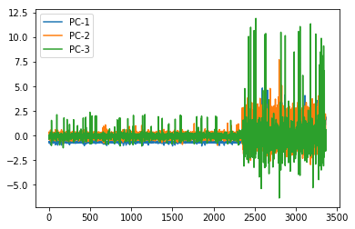

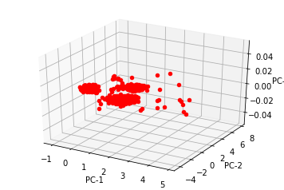

```
LPP RESULTS
(3366, 3)
```

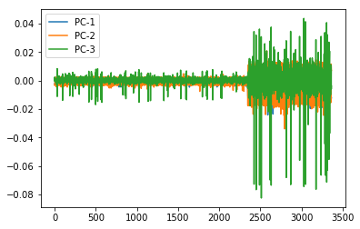

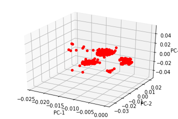

```python
print('PCA RESULTS')
input_df=dim_redn(spike_df,'PCA')
print('LPP RESULTS')
input_df_1=dim_redn(spike_df,'LPP')
```

#### 3.4 CLUSTERING

- Gaussian Mixture Model is an example of an Expectation-Maximization algorithmic approach to fitting models of Gaussians onto data so as to analyze patterns and group according to the similarity measure which clusters it into separate Gaussians. K-means is a similar EM algorithm which performs admirably well when dealing with data that form circular clusters. GMM offer a powerful upgrade over K-means, by allowing to fit Gaussians on the data distribution rather than circles, and also allow for probabilistic clustering of data points.
- A crucial problem that we run into, when clustering using such an EM method is the lack of knowledge about the number of clusters that we should be looking for. This is a very crucial problem in the spike sorting framework, in that knowing this allows us to know how many neurons that we recorded from. State-of-the-art techniques do not estimate k well when operating on datasets from 15-20 neurons, and make estimates in the order of 7-8. One simple idea is to resort to the use of information theoretic approach, like Akaike Information Criterion or Bayesian Information Criterion to help estimate the number of clusters to be found in the data.

```python
def gmm(df):
    max_neurons=20
    num_clusters=min(max_neurons,len(df))
    max_components = np.arange(1, num_clusters+1, 1)

    from sklearn.mixture import GaussianMixture
    models = [GaussianMixture(n, covariance_type='full', random_state=0).fit(df)
              for n in max_components]

    idx=0
    bic_val = np.zeros(num_clusters)
    aic_val = np.zeros(num_clusters)
    for m in models:
        bic_val[idx]=m.bic(df)
        aic_val[idx]=m.aic(df)
        idx+=1

    plt.figure()
    plt.plot(max_components, bic_val, label='BIC')
    plt.plot(max_components, aic_val, label='AIC')
    plt.legend(loc='best')
    plt.xlabel('max_components');
    plt.show()

    b=np.argmin(bic_val)
    a=np.argmin(aic_val)

    X = df
    gmm = GaussianMixture(3, covariance_type='full', random_state=0)
    labels = gmm.fit(X).predict(X)
    import collections
    counter=collections.Counter(labels)
    print(counter)

    # define the colormap
    cmap = plt.cm.jet
    # extract all colors from the .jet map
    cmaplist = [cmap(i) for i in range(cmap.N)]
    # create the new map
    cmap = cmap.from_list('Custom cmap', cmaplist, cmap.N)

    fig = plt.figure()
    ax = fig.add_subplot(111, projection='3d')
    color=['r','g','b','y','c','m', 'y', 'k']
    for i in range(X.shape[0]):
        ax.scatter(X.loc[i,0], X.loc[i,1], X.loc[i,2], c=color[labels[i]], s=40, marker='o')
    ax.set_xlabel('PC-1')
    ax.set_ylabel('PC-2')
    ax.set_zlabel('PC-3')
    plt.show()
```

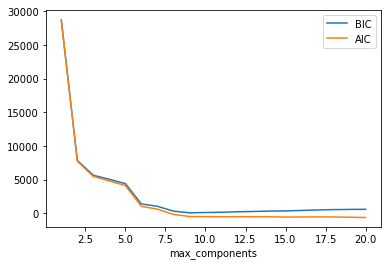

```
Counter({1: 2198, 2: 617, 0: 551})
```

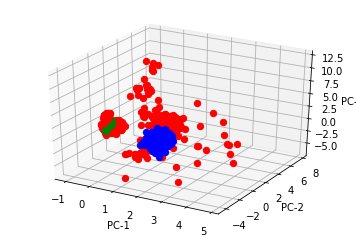

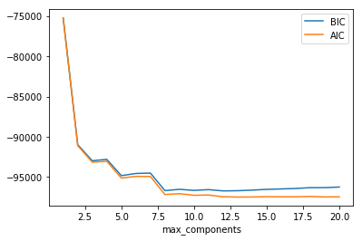

```
Counter({2: 2316, 0: 625, 1: 425})
```

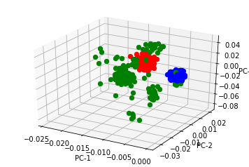

```python
gmm(input_df)
gmm(input_df_1)
```

```python
def kmeans(df,k):
    from sklearn.cluster import KMeans
    labels = KMeans(n_clusters=k, random_state=0).fit(df).labels_
    import collections
    counter=collections.Counter(labels)
    print(counter)

    X = df
    # define the colormap
    cmap = plt.cm.jet
    # extract all colors from the .jet map
    cmaplist = [cmap(i) for i in range(cmap.N)]
    # create the new map
    cmap = cmap.from_list('Custom cmap', cmaplist, cmap.N)

    fig = plt.figure()
    ax = fig.add_subplot(111, projection='3d')
    color=['r','g','b','y','c','m', 'y', 'k']
    for i in range(X.shape[0]):
        ax.scatter(X.loc[i,0], X.loc[i,1], X.loc[i,2], c=color[labels[i]], s=40, marker='o')
    ax.set_xlabel('PC-1')
    ax.set_ylabel('PC-2')
    ax.set_zlabel('PC-3')
    plt.show()
    return labels
```

```
Counter({1: 2351, 2: 664, 0: 351})
```

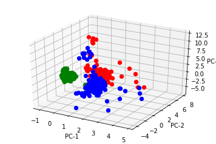

```
Counter({0: 3003, 1: 344, 2: 19})
```

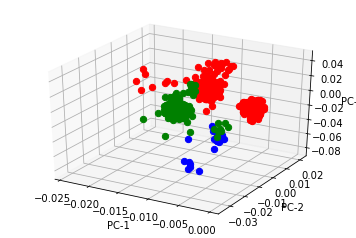

```python
km_labels = kmeans(input_df,3)
km_labels_1 = kmeans(input_df_1,3)
```

- Landmark based spectral clustering (LSC) gives an empirical advantage over the ideas of PCA-GMM and LPP-GMM. LSC finds a feature space of a graph that does away with the constraint of being orthogonal as in the case of PCA. The feature extraction method is based on finding landmark data points from the original data (3366x49) and finding a transformation of this original data as a linear combination of these landmark data points. This is achieved through nonnegative matrix factorization techniques. I use an implementation of Nadaraya Watson Kernel regression to solve for the factorization problem, and choose landmark points by virtue of random selection from the original data points.

```python
# Function to find reciprocal of Degree matrix (D^-1)
def diag_neg( D ):
    diag_elems = np.nan_to_num( np.diagonal( D ) )
    return np.diag( np.nan_to_num( np.reciprocal( diag_elems ) ) )

# Function to find reciprocal of root of Degree matrix (D^-0.5)
def diag_neg_root( D ):
    D_root = np.sqrt( D )
    D_neg_root = diag_neg( D_root )
    return D_neg_root

# Function to find the kernel weights between 2 vectors x and u
def gaussian_kernel( x, u ):
    h = 1
    norm = np.linalg.norm(x - u)
    return np.exp(-(norm**2)/(2*(h**2)))

# Link to Landmark Based Spectral Clustering Paper : https://www.cs.cmu.edu/~xinleic/papers/aaai11.pdf
def landmark_based_SC( X, k ):

    p = int( np.sqrt( X.shape[0] ) )

    # Matrix X can be viewed as 'n' data points, each of dimension 'm'
    m,n = X.shape

    # If in Sparse COO matrix convert to array
    # X = X.toarray()

    # Choose p points/indices without repetition from [0,n)
    U_idx = np.random.choice( range(n), p, replace=False )

    # Fill those p randomly chosen points from matrix X into U
    U = np.zeros((m,p))
    for i in range(p):
         U[:,i] = X[:,U_idx[i]]
    print(U.shape)


    # Number of nearest landmark points from the 'p' points of U that we need to
    # consider for calculating U_r
    r = int(p/5)
    xi = np.zeros((m,1))
    Z = np.zeros((p,n))

    for i in range(n):

        # xi indicates every datapoint of matrix
        xi[:,0] = X[:,i]

        # U_r_idx populates xi's 'r' nearest vector's(datapoints) indices in U
        from scipy import spatial
        tree = spatial.KDTree(np.transpose(U))
        U_r_idx = (tree.query(np.transpose(xi),k=r)[1]).flatten()

        # Z_list stores gaussian kernel weights between xi and 'r' nearest
        # neighbours to xi in the matrix U
        # Nadraya Watson Kernel Regression
        Z_list = np.zeros(U_r_idx.size)
        ctr=0
        for j in U_r_idx:
            Z_list[ctr] = gaussian_kernel( xi, U[:,j] )
            ctr+=1

        # Normalize and fill weights in Z matrix
        ctr=0
        if( sum( Z_list ) ):
            for j in U_r_idx:
                Z[j,i] = Z_list[ctr]/sum(Z_list)
                ctr+=1


    assert( np.isnan(Z).any() == False )

    D = np.diag( np.ravel( np.sum( Z, axis=1 ) ) )
    D_neg_root = diag_neg_root( D )

    # Compute Z_hat = D^-0.5 * Z
    Z_hat = np.dot( D_neg_root, Z )

    # SVD of Z_hat gives B_tran
    A, S, B_tran = np.linalg.svd( Z_hat, full_matrices=False )
    B = np.transpose( B_tran )

    # What B has right now would be the eigenvectors of (Z_hat * Z_hat.T)

    from sklearn.cluster import KMeans
    labels = KMeans(n_clusters=k, random_state=0).fit(B[:,0:k]).labels_
    return labels
```

```
(3366, 49)
(49, 7)
Counter({1: 2772, 0: 464, 2: 130})
(3366, 3)
```

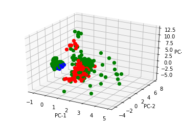

```
(3366, 3)
```

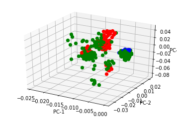

```python
graph = spike_df.as_matrix()
print(graph.shape)

labels = landmark_based_SC( graph.T, 3 )

import collections
counter=collections.Counter(labels)
print(counter)

for method in ['PCA','LPP']:
    if( method == 'PCA' ):
        from sklearn.decomposition import PCA
        pca = PCA(n_components=3, whiten=True)
        low_dim_data = pca.fit_transform(graph)

    elif( method == 'LPP' ):
        from lpproj import LocalityPreservingProjection
        lpp = LocalityPreservingProjection(n_components=3)
        low_dim_data = lpp.fit_transform(graph)

    X = pd.DataFrame(low_dim_data)
    print(X.shape)
    # define the colormap
    cmap = plt.cm.jet
    # extract all colors from the .jet map
    cmaplist = [cmap(i) for i in range(cmap.N)]
    # create the new map
    cmap = cmap.from_list('Custom cmap', cmaplist, cmap.N)

    fig = plt.figure()
    ax = fig.add_subplot(111, projection='3d')
    color=['r','g','b','y','c','m', 'y', 'k']
    for i in range(X.shape[0]):
        ax.scatter(X.loc[i,0], X.loc[i,1], X.loc[i,2], c=color[labels[i]], s=40, marker='o')
    ax.set_xlabel('PC-1')
    ax.set_ylabel('PC-2')
    ax.set_zlabel('PC-3')
    plt.show()
```